# Internet of Things

Anand Gowrishankar Sudhan

8 January 2016

# Introduction

The Dataset is about interaction of stations in a museum by various vistors with entering and leaving time. Our goal is to characterize the flow of visitors through these stations. We are trying to answer the following questions in Phase I

what is the average (or distribution) time of interaction with a given machine ? is there a relation between the duraion of an interaction and variables like weekday or hour ?

# Phase I : Exploratory Data Analysis(EDA)

## Putting the data in the correct form

```r
#Elliminate the first var(useless indexing and memory consuming)
SmallLogs <- SmallLogs[,-1]

# Setting date as POSIXct object that we can do compuations over it
SmallLogs$time <- as.POSIXct(SmallLogs$date,format="%Y-%m-%d %H:%M:%S")

#Extract scene names from the variable "scene" and convert them as factors
test=sub(".*=", "", SmallLogs$scene)
SmallLogs$scene_name<- substr(test,1, nchar(test)-1)
SmallLogs$scene_name<-as.factor(SmallLogs$scene_name)
```

# Calculating time of interaction

```r
library(dplyr)
#first log to the station
test=SmallLogs %>% group_by(station,visitor) %>% summarise(first=first(time))
 #last log to the station
test2=SmallLogs %>% group_by(station,visitor) %>% summarise(last=last(time))
dataset=merge(test,test2,by=c("station","visitor"))
#Time of interaction
dataset$time_inter=as.numeric(dataset$last-dataset$first)
```

### Distribtion of time of interaction in seconds

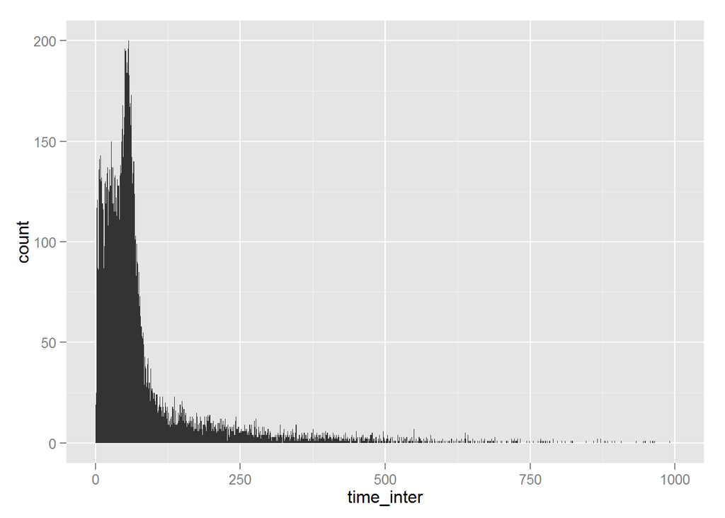

```r
library(ggplot2)
ggplot(data=dataset,aes(x=time_inter))+geom_bar(binwidth=1)+xlim(0,1000)
```

```r
summary(dataset$time_inter)
```

```
##      Min.   1st Qu.    Median      Mean   3rd Qu.      Max.
##       0.0      29.0      54.0     578.1      84.0 1068000.0
```

The time of interaction have the great concentration before 500s(8 min) and most of interactions lasts two min if outliers are eliminated. Only 515 visitors have a time of interaction greater than 500s and it because of the structure of data(a lot of errors like entering two time successively without logging out) Clearly, by showing numeric summaries of the time of interaction, the max value and the third quartile are way too separated.

We aggregate stations according to their names, for example stations **chnk01 … chnk09** will be grouped into one group *chnk0* and so on.

```r
#Agreggate stations for better visualisations
index_0=grep("cnk0",as.character(dataset$station))
index_1=grep("cnk1",as.character(dataset$station))
index_2=grep("cnk2",as.character(dataset$station))
index_3=grep("cnk3",as.character(dataset$station))
index_4=grep("cnk4",as.character(dataset$station))
index_5=grep("cnk5",as.character(dataset$station))
index_6=grep("cnk6",as.character(dataset$station))
index_7=grep("cnk7",as.character(dataset$station))

C=c(rep("cnk0",length(index_0)),rep("cnk1",length(index_1)),rep("cnk2",length(index_2)),rep("cnk3",length(index_3)),rep("cnk4",length(index_4)),rep("cnk5",length(index_5)),rep("cnk6",length(index_6)),rep("cnk7",length(index_7)))

dataset$stationAgg=C
```

### Distribution of time interaction by station

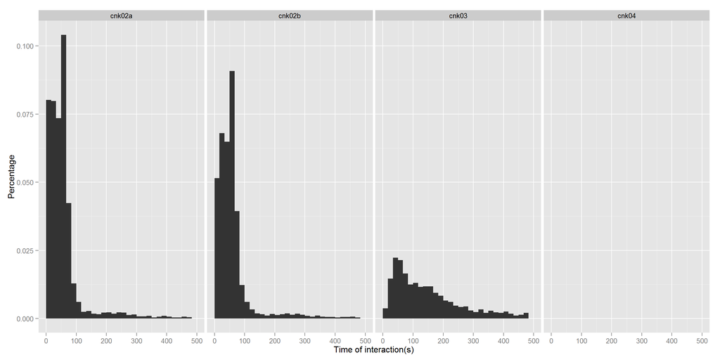

```r
ggplot(data=dataset,aes(x=time_inter))+geom_bar(aes(y =(..count..)/sum(..count..)))+facet_grid(~station)+xlim(0,500)+xlab("Time of interaction(s)")+ylab("Percentage")
```

Time of interaction according to stations tend to have different distributions, for example stations **cnk02a** and **cnk02b** have a great interaction for the time 60 seconds.

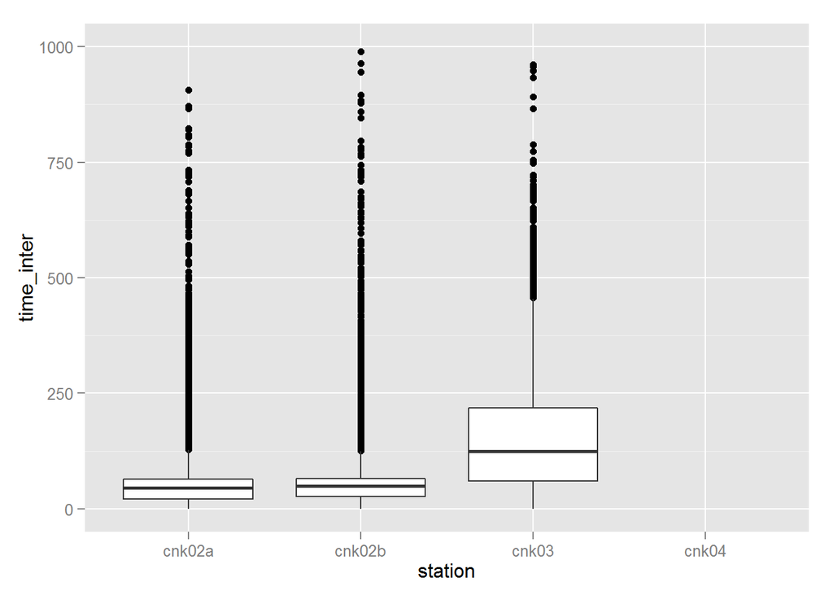

```r
#Boxplot of time interaction according to stations
ggplot(dataset,aes(y=time_inter,x=station))+geom_boxplot()+ylim(0,1000)
```

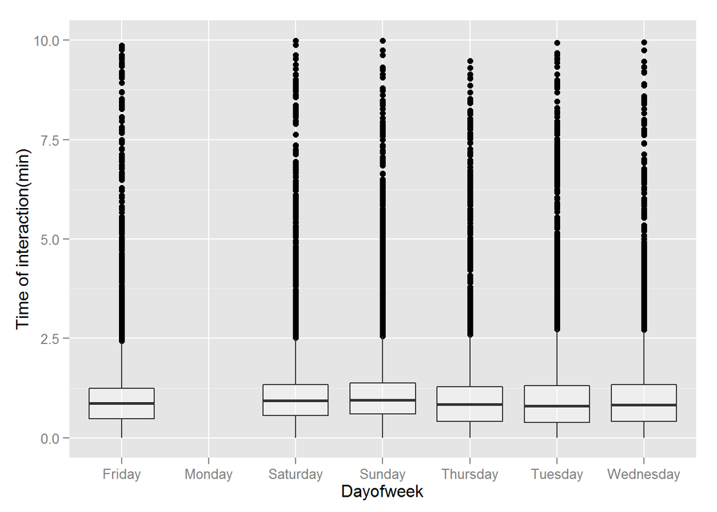

```r
dataset$Dayofweek=as.factor(weekdays(dataset$first))
ggplot(dataset,aes(x=Dayofweek,y=time_inter/60))+geom_boxplot(alpha=1/3)+ylim(0,10)+ylab("Time of interaction(min)")
```

In the over all shape of distributions according to the time of interaction, we remark that days don’t have a real influence on the time of interaction, unless the special case of Monday. We remark also a great concentration of interaction whose time is less than *2.5min*. Monday don’t figure on the plot because of the fact that the machines aren’t used heavily that day of the week(recall that we’ve used a subset, for the whole data set a very few logs are made on Monday).  
we can look at the table of count of days that visitors use the machines:

```r
table(dataset$Dayofweek)
```

```
##
##    Friday    Monday  Saturday    Sunday  Thursday   Tuesday Wednesday
##      2312         2      2600      2362      2021      2720      1836
```

```r
dataset=subset(dataset,Dayofweek!="Monday")
```

#### Using one way ANOVA to test the effect of day of the week over time of interaction

Let’s compare means of time of interaction in each day of the week using anova.

```r
aov=aov(time_inter ~ Dayofweek, data=dataset)
summary(aov)
```

```
##                Df    Sum Sq   Mean Sq F value  Pr(>F)
## Dayofweek       5 2.102e+09 420426266   3.675 0.00252 **
## Residuals   13845 1.584e+12 114403763
## ---
## Signif. codes:  0 '***' 0.001 '**' 0.01 '*' 0.05 '.' 0.1 ' ' 1
```

The output from **the one way ANOVA table** confirm that there is an influence of the days of the week over time of interaction (pvalue < 0.05), and deny then our graphical findings.

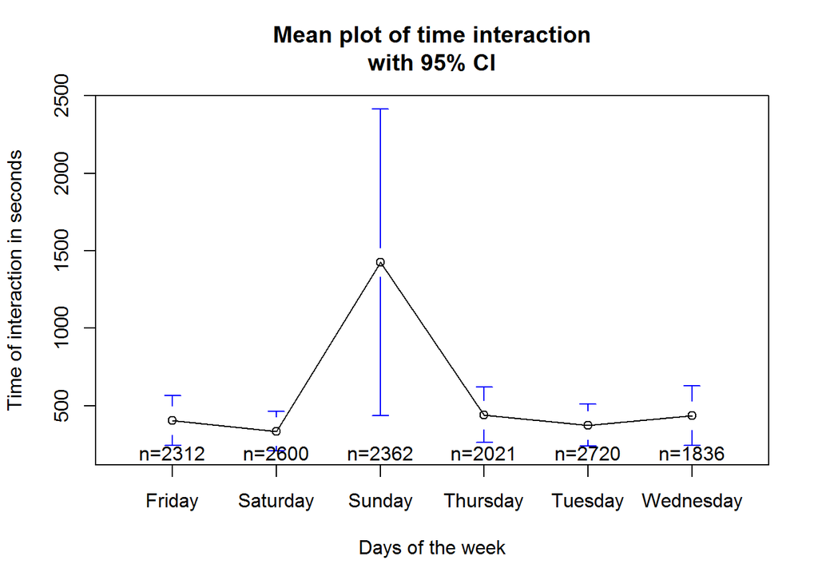

```r
library(gplots)
attach(dataset)
plotmeans(time_inter ~ Dayofweek,xlab="Days of the week",
  ylab="Time of interaction in seconds", main="Mean plot of time interaction\nwith 95% CI")
```

```r
detach(dataset)
```

```r
#hours of the day
dataset$hour<- format(dataset$first,"%H")

#Percentage for each hour of using machines
round(table(dataset$hour)*100/nrow(dataset),digits = 2)
```

```
##
##    08    09    10    11    12    13    14    15    16    17    18    19
##  0.01  1.08  6.73 12.85 15.20 14.26 14.89 14.10 12.27  6.79  1.78  0.04
```

**What features are used the most?**  
The next table will show the most used actions by visitors

```r
head(sort(table(SmallLogs$scene_name),decreasing = TRUE),10)
```

```
##
##                    Splash                   Example
##                     36541                     32379
##                     Dance                    Screen
##                     31694                     28241
##                  MainMenu CustomRemovalWarningScene
##                     10364                     10265
##              LevelOneMain                      Idle
##                      5359                      4070
##               Instruction              LevelTwoMain
##                      4059                      2354
```

```r
tb=(table(SmallLogs$scene_name))
tb=data.frame(tb)
sb=subset(tb,Freq>1500)
index=as.vector(sb[,1])
```

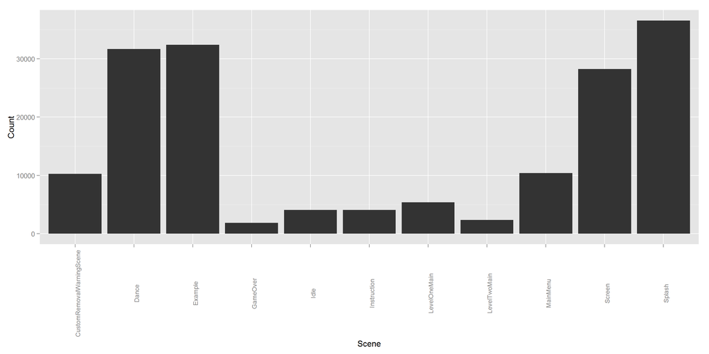

```r
#This vizualisation is about the most features used
ggplot(data = sb,aes(x=Var1,y=Freq))+geom_bar(stat="identity")+theme(axis.text.x=element_text(angle=90,size=9))+xlab("Scene")+ylab("Count")
```

# Phase II : Clustering visitors

## Define similarity dissimilarity between visitors

The first step is to find a way to characterize the dissimilarity between visitors. The relations that we’ve made to find links with descriptive statistics will help to define a profiling of users according to hour of logs, stations and patterns. To do so, and since the variables we’ve got are for the most categorical, the data set is also huge to process v via k modes (hard to be scalable) we decided to convert factors to dummy variables and then perform the k-means by scaling the resulting variables.

```r
library(dplyr)

#Adding week of the day when the log took place and the hour of logging
SmallLogs$Dayofweek=as.factor(weekdays(SmallLogs$time))
SmallLogs$date=NULL
SmallLogs$hour <- format(SmallLogs$time,"%H")

Logstocluster=merge(SmallLogs,dataset[,c(1,2,5)],by=c("station","visitor"),all=TRUE)

#This selection ignore the day of the week
Logstocluster <- select(Logstocluster,-scene,-time,-Dayofweek)
Logstocluster$hour<-as.factor(Logstocluster$hour)

#Converting factors to dummy variables
library(ade4)
test2=acm.disjonctif(Logstocluster[,-c(2,6)])
test1=select(Logstocluster,visitor,time_inter)

#final dataset
test2$visitor=test1$visitor
test2$time_inter=test1$time_inter
Logstocluster=test2
```

## Within Sum of Squared to choose **k**:

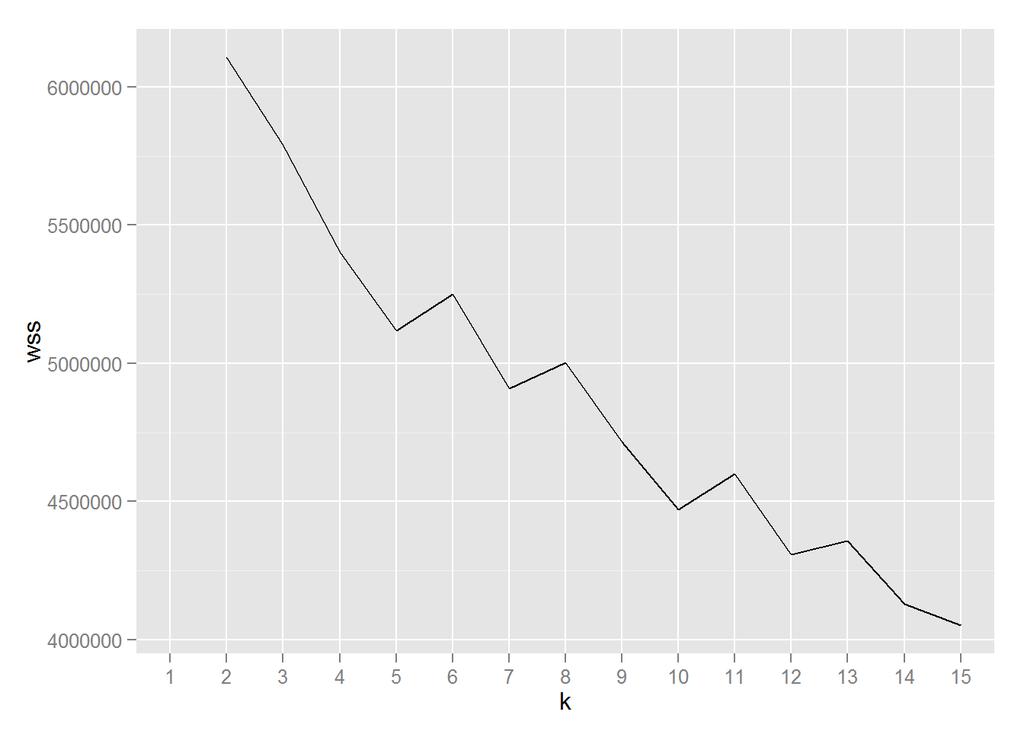

```r
n=ncol(Logstocluster)
wss=data.frame(NULL)


#Scale variables
Logstocluster.s=scale(Logstocluster[,-c(n,n-1)])
set.seed(1234)
for (i in 2:15){
  wss[i,1]=sum(fit=kmeans(Logstocluster.s,centers=i)$withinss)
}
colnames(wss)="wss"
wss$k=seq(1,15,1)
ggplot(data = wss,aes(x=k,y=wss))+geom_line()+scale_x_discrete(breaks=seq(1,15,1))
```

# Using K-means with k=4

```r
km=kmeans(Logstocluster.s,4,nstart=100,iter.max = 100)
summary(km)
```

```
##              Length Class  Mode
## cluster      170000 -none- numeric
## centers         148 -none- numeric
## totss             1 -none- numeric
## withinss          4 -none- numeric
## tot.withinss      1 -none- numeric
## betweenss         1 -none- numeric
## size              4 -none- numeric
## iter              1 -none- numeric
## ifault            1 -none- numeric
```

```r
Logstocluster$cluster=as.factor(km$cluster)
SmallLogs$cluster=as.factor(km$cluster)
```

```r
#Size of each cluster
km$size
```

```
## [1] 74552 68197  2354 24897
```

# Interpretation of clusters

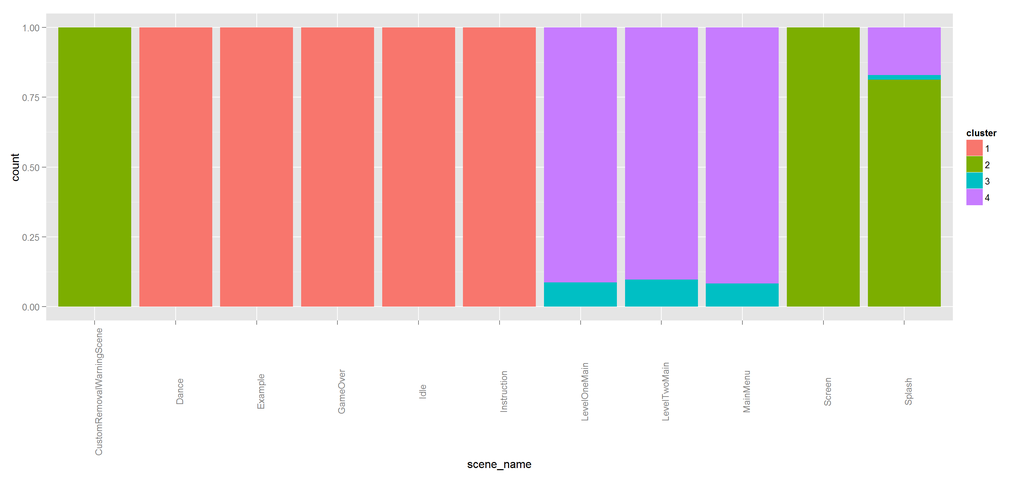

```r
#Plotting clusters against scenes
library(ggplot2)
ggplot(data=subset(SmallLogs,scene_name%in%index),aes(x=scene_name,fill=cluster))+geom_bar(position = "fill")+theme(axis.text.x=element_text(angle=90))
```

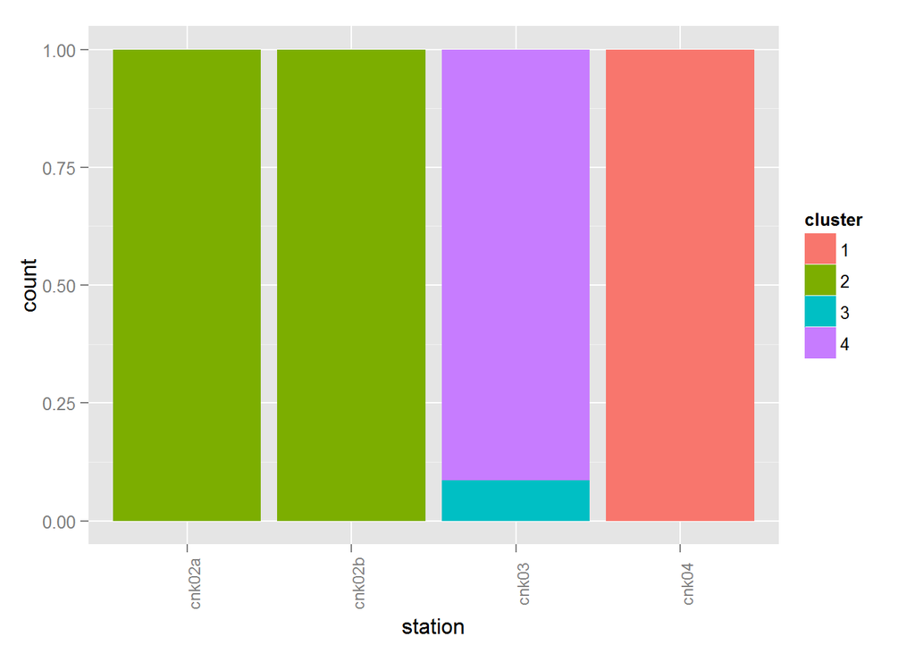

```r
#Station
ggplot(data=SmallLogs,aes(x=station,fill=cluster))+geom_bar(position = "fill")+theme(axis.text.x=element_text(angle=90,size=9))
```

# Inference - KMeans Results

The caracterization of clusters is made by plotting variables used in the clustering and the resulting clusters. So the above plot help us to define the caracteristic of each cluster:

1.Dance, Example, Game over corresponding to the first cluster and it correspond to the **cnk04** machine who is believed to be a station with dancing patterns. This machine have a really small amount of time of interaction and can be described suitable for occasional players.

2.Stations **cnk02a** and **cnk02b** are believed to be typical station machines, almost all users use these two stations who are believed to be regular stations at the museum that everyone uses. The time of interaction is quite short (<5min), although, both stations are used intensivly.

3.Station **cnk03** belong to the 4th cluster, and the most pattern used in this station are Multi level Main (LevelOneMain, LevelTwoMain,etc.). According to the boxplot of time interaction, this station is used with a great amount of time of interaction and may contain multilevel stages to accomplish the goal behind it. So users spend too much time with it and can be decribed as ‘addictive’ for visitors.